# Data Exploring

```python
import numpy as np
import pandas as pd
import matplotlib.pyplot as plt
import seaborn as sns
```

```python
df = pd.read_csv('winequality-red.csv')
```

```python
df.head()
```

|  | fixed acidity | volatile acidity | citric acid | residual sugar | chlorides | free sulfur dioxide | total sulfur dioxide | density | pH | sulphates | alcohol | quality |
| --- | --- | --- | --- | --- | --- | --- | --- | --- | --- | --- | --- | --- |
| 0 | 7.4 | 0.70 | 0.00 | 1.9 | 0.076 | 11.0 | 34.0 | 0.9978 | 3.51 | 0.56 | 9.4 | 5 |
| 1 | 7.8 | 0.88 | 0.00 | 2.6 | 0.098 | 25.0 | 67.0 | 0.9968 | 3.20 | 0.68 | 9.8 | 5 |
| 2 | 7.8 | 0.76 | 0.04 | 2.3 | 0.092 | 15.0 | 54.0 | 0.9970 | 3.26 | 0.65 | 9.8 | 5 |
| 3 | 11.2 | 0.28 | 0.56 | 1.9 | 0.075 | 17.0 | 60.0 | 0.9980 | 3.16 | 0.58 | 9.8 | 6 |
| 4 | 7.4 | 0.70 | 0.00 | 1.9 | 0.076 | 11.0 | 34.0 | 0.9978 | 3.51 | 0.56 | 9.4 | 5 |

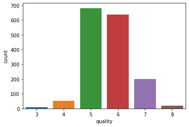

```python
sns.countplot(x=df['quality'])
```

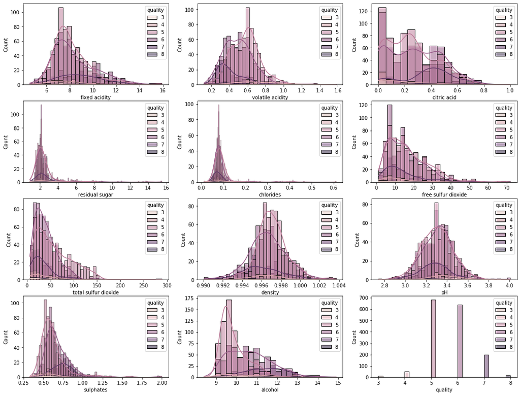

```python
fig, axes = plt.subplots(nrows=4, ncols=3, figsize=(18, 14))
sns.histplot(data=df, x="fixed acidity", kde=True,ax=axes[0][0],hue='quality')
sns.histplot(data=df, x="volatile acidity", kde=True,ax=axes[0][1],hue='quality')
sns.histplot(data=df, x="citric acid", kde=True,ax=axes[0][2],hue='quality')
sns.histplot(data=df, x="residual sugar", kde=True,ax=axes[1][0],hue='quality')
sns.histplot(data=df, x="chlorides", kde=True,ax=axes[1][1],hue='quality')
sns.histplot(data=df, x="free sulfur dioxide", kde=True,ax=axes[1][2],hue='quality')
sns.histplot(data=df, x="total sulfur dioxide", kde=True,ax=axes[2][0],hue='quality')
sns.histplot(data=df, x="density", kde=True,ax=axes[2][1],hue='quality')
sns.histplot(data=df, x="pH", kde=True,ax=axes[2][2],hue='quality')
sns.histplot(data=df, x="sulphates", kde=True,ax=axes[3][0],hue='quality')
sns.histplot(data=df, x="alcohol", kde=True,ax=axes[3][1],hue='quality')
sns.histplot(data=df, x="quality", kde=True,ax=axes[3][2],hue='quality')
```

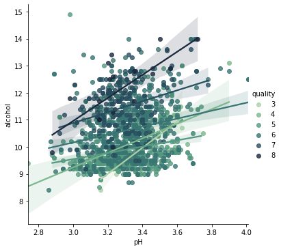

```python
plt.figure(figsize=(10,7))
sns.lmplot(x='pH',y='alcohol', data=df, hue='quality', palette="ch:r=-.5,l=.75")
```

i cant see any promising relation among them

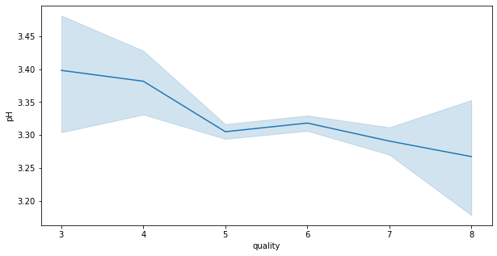

```python
plt.figure(figsize=(10,5))
sns.lineplot(x=df['quality'],y=df['pH'])
```

looks like as quality increase ph decreases

```python
df.corr()['quality']
```

```
fixed acidity           0.124052
volatile acidity       -0.390558
citric acid             0.226373
residual sugar          0.013732
chlorides              -0.128907
free sulfur dioxide    -0.050656
total sulfur dioxide   -0.185100
density                -0.174919
pH                     -0.057731
sulphates               0.251397
alcohol                 0.476166
quality                 1.000000
Name: quality, dtype: float64
```

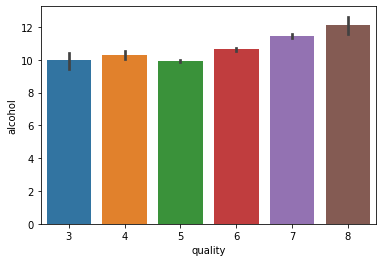

```python
sns.barplot(x=df['quality'],y=df['alcohol'])
```

looks like alcohol and quality are directly related

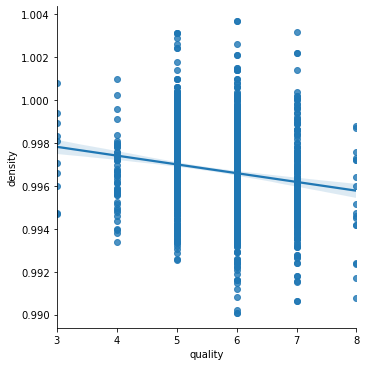

```python
sns.lmplot(x='quality',y='density',data=df)
```

as density decrease quality increases. we are not able to see much varies because the value in variance of density is very less

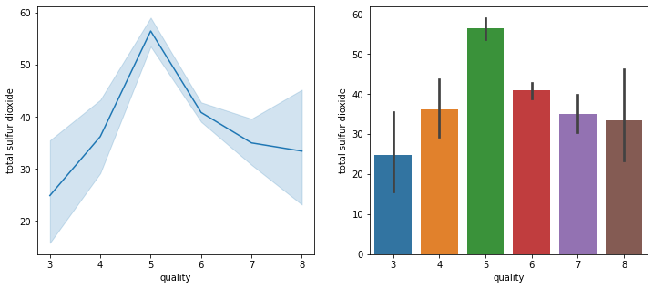

```python
plt.figure(figsize=(12,5))
plt.subplot(1,2,1)
sns.lineplot(y='total sulfur dioxide',x='quality',data=df)

plt.subplot(1,2,2)
sns.barplot(y='total sulfur dioxide',x='quality',data=df)
```

i dont see any promissing relation between them

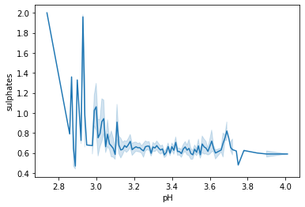

```python
sns.lineplot(y='sulphates',x='pH',data=df)
```

we can clearly see as the sulphate value decreases pH increases look like a negative realtion among them

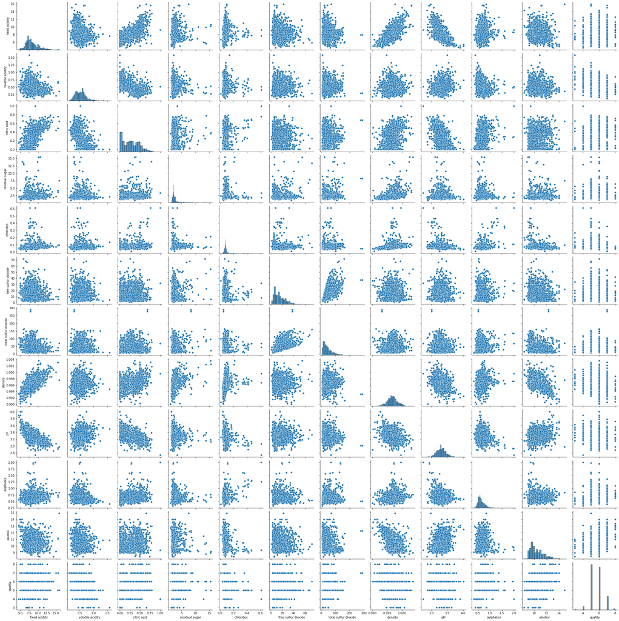

```python
sns.pairplot(df)
```

> fixed acidity had denisty have a direct relation.

> simiraly fixed acidity and pH have negative relation.

> looks like alcohol and density also has a negative relation

```python
df.isna().sum()
```

```
fixed acidity           0
volatile acidity        0
citric acid             0
residual sugar          0
chlorides               0
free sulfur dioxide     0
total sulfur dioxide    0
density                 0
pH                      0
sulphates               0
alcohol                 0
quality                 0
dtype: int64
```

# Handling imbalance

```python
from sklearn.utils import resample,shuffle

five =df[df['quality']==5]
six = df[df['quality']==6]
three = df[df['quality']==3]
four = df[df['quality']==4]
seven = df[df['quality']==7]
eight = df[df['quality']==8]

upsampled1 = resample(three, replace=True, n_samples=five.shape[0])
upsampled2 = resample(four, replace=True, n_samples=five.shape[0])
upsampled3 = resample(six, replace=True, n_samples=five.shape[0])
upsampled4 = resample(seven, replace=True, n_samples=five.shape[0])
upsampled5 = resample(eight, replace=True, n_samples=five.shape[0])

df = pd.concat([five,upsampled1,upsampled2,upsampled3,upsampled4,upsampled5])

df = shuffle(df)
```

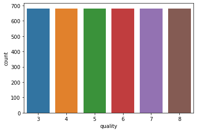

```python
 sns.countplot(x=df['quality'])
```

# Model Building

```python
x = df.drop('quality',axis=1)
y = df['quality']
```

```python
from sklearn.model_selection import train_test_split

x_train,x_test,y_train,y_test = train_test_split(x,y,train_size=0.7,random_state=101)
```

1)Decision Tree

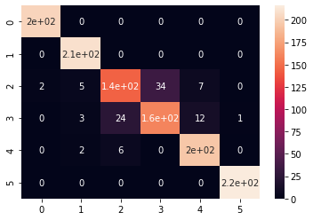

```python
from sklearn.tree import DecisionTreeClassifier
from sklearn.metrics import accuracy_score,confusion_matrix

dt = DecisionTreeClassifier()
dt.fit(x_train,y_train)
dt_predict = dt.predict(x_test)
dt_cm = confusion_matrix(y_test,dt_predict)
sns.heatmap(dt_cm,annot=True)
```

```python
accuracy_score(y_test,dt_predict)
```

```
0.9216965742251223
```

2)Random forest

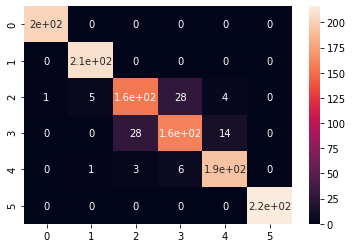

```python
from sklearn.ensemble import RandomForestClassifier

rf = RandomForestClassifier()
rf.fit(x_train,y_train)
rf_predict = rf.predict(x_test)
rf_cm = confusion_matrix(y_test,rf_predict)
sns.heatmap(rf_cm,annot=True)
```

```python
accuracy_score(y_test,rf_predict)
```

```
0.9265905383360522
```

3)support vector machine

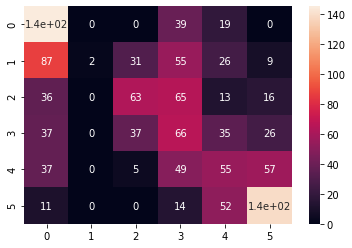

```python
from sklearn.svm import SVC

svm = SVC()
svm.fit(x_train,y_train)
svm_predict = svm.predict(x_test)
svm_cm = confusion_matrix(y_test,svm_predict)
sns.heatmap(svm_cm,annot=True)
```

```python
accuracy_score(y_test,svm_predict)
```

```
0.3833605220228385
```

4)K-Nearest Neighbor

```python
accuracy_score(y_test,kn_predict)
```

[output not shown]

```
0.800978792822186
```

5)Naive Bayes

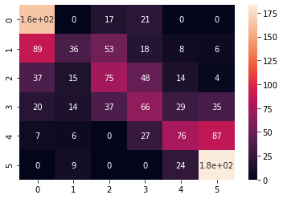

```python
from sklearn.naive_bayes import GaussianNB

nb = GaussianNB()
nb.fit(x_train,y_train)
nb_predict = nb.predict(x_test)
sns.heatmap(confusion_matrix(y_test,nb_predict),annot=True)
```

```python
accuracy_score(y_test,nb_predict)
```

```
0.4902120717781403
```

from all the models above Random forest is the best one as it accuracy score is 92.65%